# DATA151: Tidyr and Joins

### Learning Objectives

In this lesson students will gain more practice with the `tidyverse` with a particular focus on wrangling the `tidyr` package.

This lesson covers:

- `tidyr` Package
  - `pivot_longer()` (older version: `gather()`)
  - `pivot_wider()` (older version `spread()`)
  - `unite()`
  - `separate()`
- Joins: `left_join`, `inner_join`, `right_join`

UPDATED: October 2024

Before you start you will need to load the `tidyverse`

```r
library(tidyverse)
```

### PART I: `tidyr`

### Does your data spark joy?

#### Example 1: Football

##### Step 1: Get the data

```r
library(openintro)
data("helium")

## Look at data
head(helium)
```

```
## # A tibble: 6 × 3
##   trial   air helium
##   <int> <int>  <int>
## 1     1    25     25
## 2     2    23     16
## 3     3    18     25
## 4     4    16     14
## 5     5    35     23
## 6     6    15     29
```

This is not the format we want our data to be in! Let’s wrangle it!

##### Step 2: Wrangle

```r
### WRANGLE
football<-helium%>%
  pivot_longer(!trial, names_to = "airType", values_to="yards")

head(football)
```

```
## # A tibble: 6 × 3
##   trial airType yards
##   <int> <chr>   <int>
## 1     1 air        25
## 2     1 helium     25
## 3     2 air        23
## 4     2 helium     16
## 5     3 air        18
## 6     3 helium     25
```

```r
# AN OLDER FUNCTION FOR THIS IS GATHER
#football<-helium%>%
#  gather("airType", "yards", -trial)
```

#### Think about it!

How does `pivot_longer` work?

[output not shown]

##### Step 3: Visualize

Why do we need to have this format?

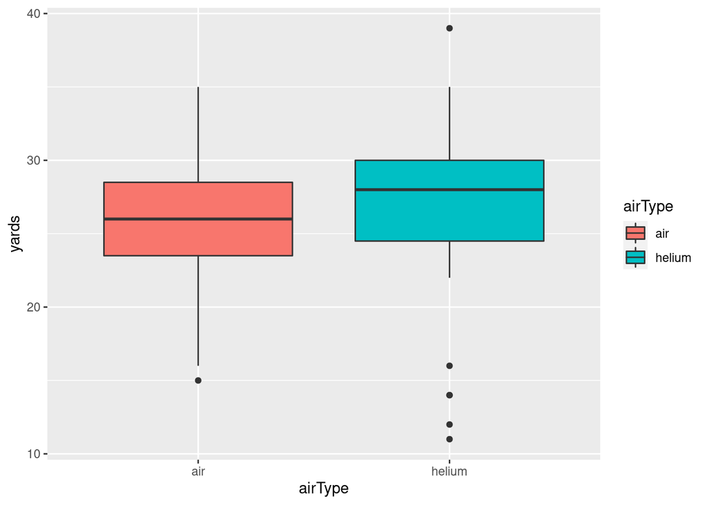

```r
## ggplot
## INSERT CODE HERE ##
ggplot(data = football, aes(x = airType, y = yards, fill = airType))+
  geom_boxplot()
```

#### Toy Example

##### Step 1: Generate Data

```r
# generate stock market data
set.seed(1)
stocks <- data.frame(
  time = as.Date('2009-01-01') + 0:9,
  X = rnorm(10, 20, 1),
  Y = rnorm(10, 20, 2),
  Z = rnorm(10, 20, 4)
)
stocks
```

```
##          time        X        Y        Z
## 1  2009-01-01 19.37355 23.02356 23.67591
## 2  2009-01-02 20.18364 20.77969 23.12855
## 3  2009-01-03 19.16437 18.75752 20.29826
## 4  2009-01-04 21.59528 15.57060 12.04259
## 5  2009-01-05 20.32951 22.24986 22.47930
## 6  2009-01-06 19.17953 19.91013 19.77549
## 7  2009-01-07 20.48743 19.96762 19.37682
## 8  2009-01-08 20.73832 21.88767 14.11699
## 9  2009-01-09 20.57578 21.64244 18.08740
## 10 2009-01-10 19.69461 21.18780 21.67177
```

##### Step 2: Pivot Longer

```r
# pivot_longer
## INSERT CODE HERE ##
stocksL<-stocks%>%
  pivot_longer(-time, names_to="stock", values_to="price")

head(stocksL)
```

```
## # A tibble: 6 × 3
##   time       stock price
##   <date>     <chr> <dbl>
## 1 2009-01-01 X      19.4
## 2 2009-01-01 Y      23.0
## 3 2009-01-01 Z      23.7
## 4 2009-01-02 X      20.2
## 5 2009-01-02 Y      20.8
## 6 2009-01-02 Z      23.1
```

```r
# OLD METHOD gather
#stocksG<-stocks%>%
#  gather(key=stock, value=price, -time )
```

##### Combine `tidyr` and `dplyr`

```r
stocks%>%
  pivot_longer(-time, names_to="stock", values_to="price")%>%
  group_by(stock)%>%
  summarise(min=min(price),
            max=max(price))
```

```
## # A tibble: 3 × 3
##   stock   min   max
##   <chr> <dbl> <dbl>
## 1 X      19.2  21.6
## 2 Y      15.6  23.0
## 3 Z      12.0  23.7
```

##### Step 3: Visualize

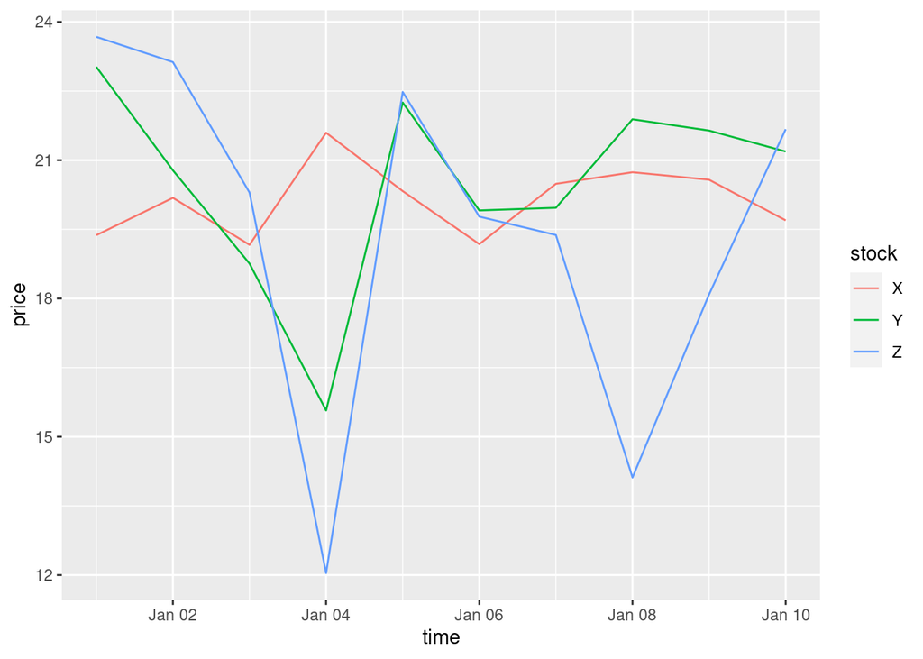

```r
ggplot(stocksL, aes(time, price, color=stock))+
  geom_line()
```

##### Step 4: Pivot Wider

```r
stocksW<-stocksL%>%
  pivot_wider(names_from = stock, values_from = price)

head(stocksW)
```

```
## # A tibble: 6 × 4
##   time           X     Y     Z
##   <date>     <dbl> <dbl> <dbl>
## 1 2009-01-01  19.4  23.0  23.7
## 2 2009-01-02  20.2  20.8  23.1
## 3 2009-01-03  19.2  18.8  20.3
## 4 2009-01-04  21.6  15.6  12.0
## 5 2009-01-05  20.3  22.2  22.5
## 6 2009-01-06  19.2  19.9  19.8
```

```r
## OLD CODE spread
#stocksS<-stocksG%>%
#  spread(key=stock, value=price)
```

#### Real World Example: Hawaii Tourism

##### Step 1: Import Data

```r
## IMPORT THE DATA
## TRY TO IMPORT FILE ##

### JUST IN CASE HERE IS THE LINK ###
hi <- read.csv("https://raw.githubusercontent.com/kitadasmalley/DATA151/main/Data/Hawaii_Tourism.csv", header=TRUE)
```

##### Step 2: Look at the structure

```r
## LOOK AT THE STRUCTURE
## INSERT CODE HERE ##
str(hi)
```

```
## 'data.frame':    121 obs. of  26 variables:
##  $ Group    : chr  "All visitors by air" "Hotel-only visitors" "First-time visitors" "Honeymoon visitors" ...
##  $ Indicator: chr  "LOS Statewide" "LOS Statewide" "LOS Statewide" "LOS Statewide" ...
##  $ Units    : chr  "days" "days" "days" "days" ...
##  $ X1999    : num  8.9 7.4 8.1 7.3 6.4 5.6 5.9 5.3 6.7 5.6 ...
##  $ X2000    : num  8.9 7.2 7.9 7.4 6.6 5.7 5.9 5.3 6.8 5.4 ...
##  $ X2001    : num  9.2 7.5 8.4 NA 6.8 5.9 6.3 NA 6.9 5.7 ...
##  $ X2002    : num  9.4 7.7 8.5 NA 7 6.2 6.4 NA 7.2 5.9 ...
##  $ X2003    : num  9.2 7.7 8.5 NA 6.9 6.1 6.3 NA 7.3 6.3 ...
##  $ X2004    : num  9.1 7.3 8.2 8 6.9 5.9 6.2 5.5 7.5 6.2 ...
##  $ X2005    : num  9.1 7.3 8.3 7.8 6.9 6 6.3 5.5 7.5 6.3 ...
##  $ X2006    : num  9.2 7.3 8.3 7.9 6.9 6 6.2 5.5 7.4 6.3 ...
##  $ X2007    : num  9.2 7.2 8.4 7.9 6.8 5.9 6.2 5.5 7.3 6.2 ...
##  $ X2008    : num  9.4 7.3 8.6 7.8 7.1 6.1 6.5 5.6 7.8 6.3 ...
##  $ X2009    : num  9.4 7.3 8.6 7.6 7.3 6.2 6.7 5.6 8 6.4 ...
##  $ X2010    : num  9.4 7.4 8.5 7.7 7.4 6.2 6.7 5.8 8.1 6.5 ...
##  $ X2011    : num  9.5 7.4 8.5 7.6 7.4 6.4 6.6 5.7 8.1 5.9 ...
##  $ X2012    : num  9.4 7.3 8.4 7.5 7.3 6.2 6.5 5.8 8.1 6.3 ...
##  $ X2013    : num  9.3 7.2 8.3 7.5 7 6 6.3 5.6 8.2 6.3 ...
##  $ X2014    : num  9.2 7.2 8.3 7.6 6.8 5.9 6.1 5.7 8.2 6.5 ...
##  $ X2015    : num  9.1 7.2 8.3 7.5 6.8 5.9 6.2 5.6 8.2 6.5 ...
##  $ X2016    : num  9 7.2 8.2 7.5 6.8 5.9 6.2 5.7 8.1 6.6 ...
##  $ X2017    : num  9 7.3 8.4 7.6 6.7 6 6.2 5.7 8 6.6 ...
##  $ X2018    : num  9 7.3 8.5 7.7 6.9 6.1 6.4 5.8 8.1 6.7 ...
##  $ X2019    : num  8.8 7.1 8.2 7.7 6.8 6 6.3 5.9 7.9 6.7 ...
##  $ X2020    : num  10.6 7.6 NA 8.1 8.5 6.5 NA 6.1 9.5 7.1 ...
##  $ X2021    : num  9.6 7.9 8.8 9.1 8.1 6.9 7.3 6.3 8.7 7.4 ...
```

##### Step 3: Rename the columns

```r
## RENAME THE COLUMNS
## INSERT CODE HERE ##
colnames(hi)[4:26]<-1999:2021

names(hi)
```

```
##  [1] "Group"     "Indicator" "Units"     "1999"      "2000"      "2001"
##  [7] "2002"      "2003"      "2004"      "2005"      "2006"      "2007"
## [13] "2008"      "2009"      "2010"      "2011"      "2012"      "2013"
## [19] "2014"      "2015"      "2016"      "2017"      "2018"      "2019"
## [25] "2020"      "2021"
```

##### Step 4: Tidy Data with `pivot_longer()`

```r
## TIDY YOUR DATA
## INSERT CODE HERE ##
hiL<-hi%>%
  filter(Units=="days")%>%
  select(-Units)%>%
  pivot_longer(-c(Group, Indicator), names_to = "year", values_to = "days")

## LOOK AT THE NEW STRUCTURE
str(hiL)
```

```
## tibble [2,691 × 4] (S3: tbl_df/tbl/data.frame)
##  $ Group    : chr [1:2691] "All visitors by air" "All visitors by air" "All visitors by air" "All visitors by air" ...
##  $ Indicator: chr [1:2691] "LOS Statewide" "LOS Statewide" "LOS Statewide" "LOS Statewide" ...
##  $ year     : chr [1:2691] "1999" "2000" "2001" "2002" ...
##  $ days     : num [1:2691] 8.9 8.9 9.2 9.4 9.2 9.1 9.1 9.2 9.2 9.4 ...
```

##### Step 5: Visualize Trends

```r
## YEAR NEEDS TO BE NUMERIC TO PLOT
## INSERT CODE HERE ##
hiL$year<-as.numeric(hiL$year)

str(hiL)
```

```
## tibble [2,691 × 4] (S3: tbl_df/tbl/data.frame)
##  $ Group    : chr [1:2691] "All visitors by air" "All visitors by air" "All visitors by air" "All visitors by air" ...
##  $ Indicator: chr [1:2691] "LOS Statewide" "LOS Statewide" "LOS Statewide" "LOS Statewide" ...
##  $ year     : num [1:2691] 1999 2000 2001 2002 2003 ...
##  $ days     : num [1:2691] 8.9 8.9 9.2 9.4 9.2 9.1 9.1 9.2 9.2 9.4 ...
```

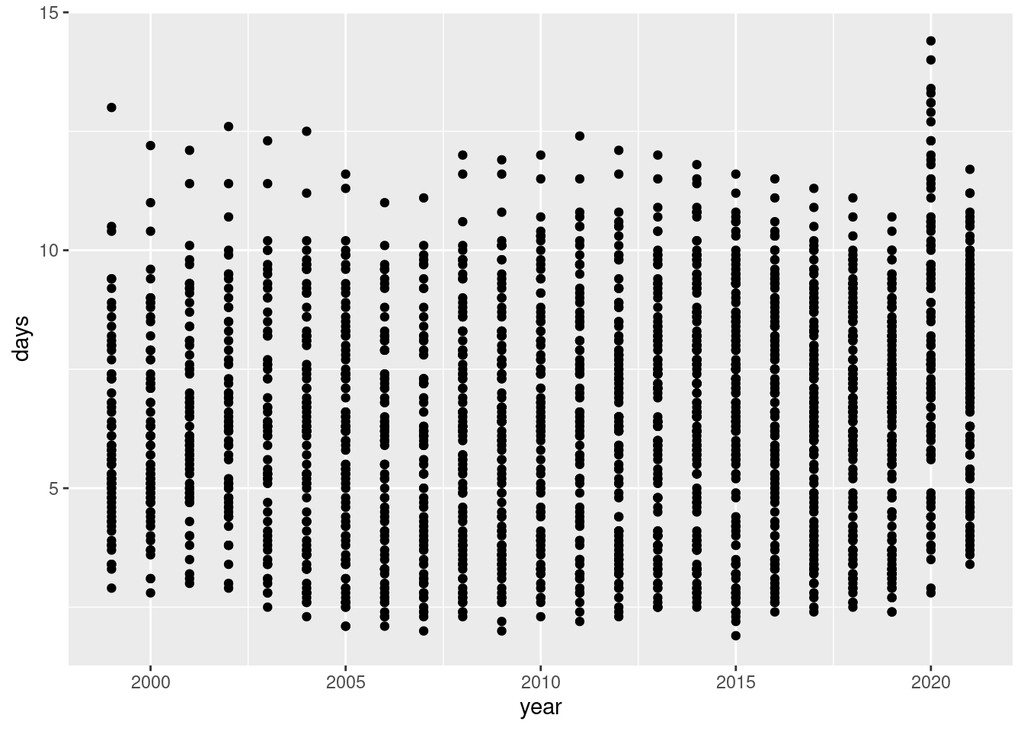

```r
## SCATTERPLOT WITH TREND
## INSERT CODE HERE ##
ggplot(hiL, aes(x=year, y=days))+
  geom_point()
```

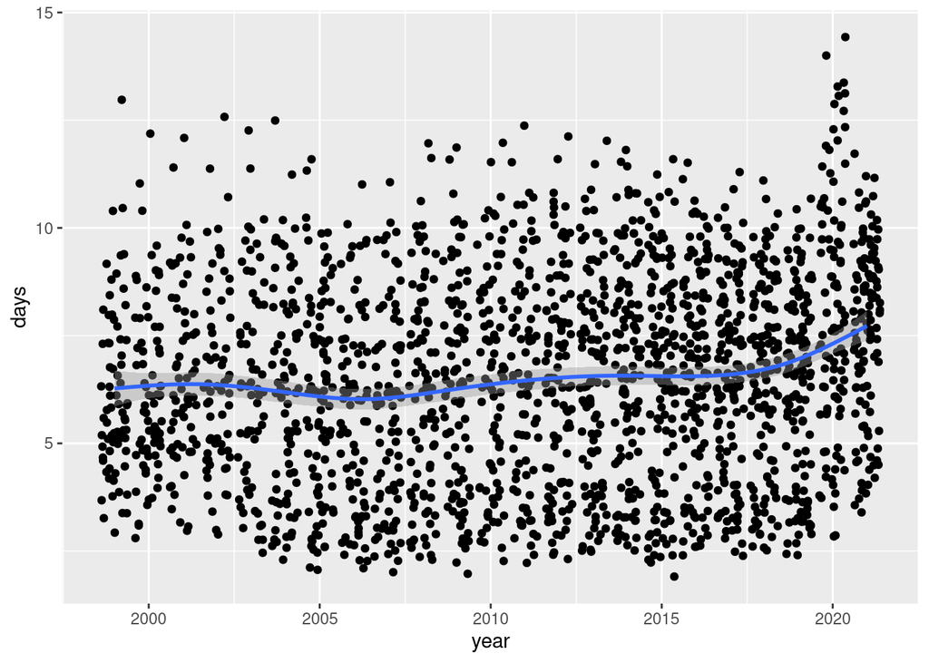

```r
## TRY GEOM_JITTER
## INSERT CODE HERE ##
ggplot(hiL, aes(x=year, y=days))+
  geom_jitter()+
  geom_smooth()
```